# 3. Frequency - Zero Inflated - Poisson

```r
library(MASS)
library(lmtest)
library(pscl)
library(xgboost)
library(ggplot2)
library(caret)
```

```r
source('/home/kate/code/Utils/MyFunctions.R')
```

```r
ModelsDir <- '/home/kate/Research/Property/Models/'
UseSavedIfExists <- FALSE
```

```r
training_data <- read.csv("/home/kate/Research/Property/Data/property_wcf_training.csv", header=TRUE)
testing_data <- read.csv("/home/kate/Research/Property/Data/property_wcf_testing.csv", header=TRUE)
```

NB work with factors and because some numerical columns are factors (ordered) I convert them in factors explicitly. I may need to do this for some other columns which are Yes/No.

```r
training_data$appl_fail_3_blk <- as.factor( training_data$appl_fail_3_blk )
training_data$fixture_leak_3_blk <- as.factor( training_data$fixture_leak_3_blk )
training_data$pipe_froze_3_blk <- as.factor( training_data$pipe_froze_3_blk )
training_data$plumb_leak_3_blk <- as.factor( training_data$plumb_leak_3_blk )
training_data$rep_cost_3_blk <- as.factor( training_data$rep_cost_3_blk )
training_data$ustructure_fail_3_blk <- as.factor( training_data$ustructure_fail_3_blk )
training_data$waterh_fail_3_blk <- as.factor( training_data$waterh_fail_3_blk )
```

```r
testing_data$appl_fail_3_blk <- as.factor( testing_data$appl_fail_3_blk )
testing_data$fixture_leak_3_blk <- as.factor( testing_data$fixture_leak_3_blk )
testing_data$pipe_froze_3_blk <- as.factor( testing_data$pipe_froze_3_blk )
testing_data$plumb_leak_3_blk <- as.factor( testing_data$plumb_leak_3_blk )
testing_data$rep_cost_3_blk <- as.factor( testing_data$rep_cost_3_blk )
testing_data$ustructure_fail_3_blk <- as.factor( testing_data$ustructure_fail_3_blk )
testing_data$waterh_fail_3_blk <- as.factor( testing_data$waterh_fail_3_blk )
```

```r
max_yearbuilt <- max(training_data$yearbuilt)
max_sqft <- max(training_data$sqft)
max_water_risk_3_blk <- max(training_data$water_risk_3_blk)
max_water_risk_fre_3_blk <- max(training_data$water_risk_fre_3_blk)
max_water_risk_sev_3_blk <- max(training_data$water_risk_sev_3_blk)
```

```r
training_data$log_norm_yearbult <- log(training_data$yearbuilt/max_yearbuilt)
training_data$log_norm_sqft <- log(training_data$sqft/max_sqft)
training_data$log_norm_water_risk_3_blk <- log(training_data$water_risk_3_blk/max_water_risk_3_blk)
training_data$log_norm_water_risk_fre_3_blk <- log(training_data$water_risk_fre_3_blk/max_water_risk_fre_3_blk)
training_data$log_norm_water_risk_sev_3_blk <- log(training_data$sqft/max_water_risk_sev_3_blk)
```

```r
testing_data$log_norm_yearbult <- log(testing_data$yearbuilt/max_yearbuilt)
testing_data$log_norm_sqft <- log(testing_data$sqft/max_sqft)
testing_data$log_norm_water_risk_3_blk <- log(testing_data$water_risk_3_blk/max_water_risk_3_blk)
testing_data$log_norm_water_risk_fre_3_blk <- log(testing_data$water_risk_fre_3_blk/max_water_risk_fre_3_blk)
testing_data$log_norm_water_risk_sev_3_blk <- log(testing_data$sqft/max_water_risk_sev_3_blk)
```

```r
training_data$stories <- as.factor(training_data$stories)
training_data$units <- as.factor(training_data$units)
training_data$secondaryresidence <- as.factor(training_data$secondaryresidence)
training_data$sprinklersystem <- as.factor(training_data$sprinklersystem)
training_data$firealarmtype <- as.factor(training_data$firealarmtype)
training_data$waterdetectiondevice <- as.factor(training_data$waterdetectiondevice)
training_data$propertymanager <- as.factor(training_data$propertymanager)
training_data$cova_deductible <- as.factor(training_data$cova_deductible)
training_data$cova_limit       <- as.factor(training_data$cova_limit      )
training_data$waterded <- as.factor(training_data$waterded)
training_data$protectionclass <- as.factor(training_data$protectionclass)
training_data$fire_risk_model_score <- as.factor(training_data$fire_risk_model_score)
training_data$ordinanceorlawpct <- as.factor(training_data$ordinanceorlawpct)
training_data$functionalreplacementcost <- as.factor(training_data$functionalreplacementcost)
training_data$homegardcreditind <- as.factor(training_data$homegardcreditind)
training_data$landlordind <- as.factor(training_data$landlordind)
training_data$rentersinsurance <- as.factor(training_data$rentersinsurance)
training_data$burglaryalarmtype <- as.factor(training_data$burglaryalarmtype)
training_data$propertymanager <- as.factor(training_data$propertymanager)
```

```r
testing_data$stories <- as.factor(testing_data$stories)
testing_data$units <- as.factor(testing_data$units)
testing_data$secondaryresidence <- as.factor(testing_data$secondaryresidence)
testing_data$sprinklersystem <- as.factor(testing_data$sprinklersystem)
testing_data$firealarmtype <- as.factor(testing_data$firealarmtype)
testing_data$waterdetectiondevice <- as.factor(testing_data$waterdetectiondevice)
testing_data$propertymanager <- as.factor(testing_data$propertymanager)
testing_data$cova_deductible <- as.factor(testing_data$cova_deductible)
testing_data$cova_limit       <- as.factor(testing_data$cova_limit      )
testing_data$waterded <- as.factor(testing_data$waterded)
testing_data$protectionclass <- as.factor(testing_data$protectionclass)
testing_data$fire_risk_model_score <- as.factor(testing_data$fire_risk_model_score)
testing_data$ordinanceorlawpct <- as.factor(testing_data$ordinanceorlawpct)
testing_data$functionalreplacementcost <- as.factor(testing_data$functionalreplacementcost)
testing_data$homegardcreditind <- as.factor(testing_data$homegardcreditind)
testing_data$landlordind <- as.factor(testing_data$landlordind)
testing_data$rentersinsurance <- as.factor(testing_data$rentersinsurance)
testing_data$burglaryalarmtype <- as.factor(testing_data$burglaryalarmtype)
testing_data$propertymanager <- as.factor(testing_data$propertymanager)
```

```r
#unique numclaims values
numclaims <- unique(training_data$cova_ic_nc_water)
```

## Modeling

```r
formula_all <-  cova_ic_nc_water ~
log_norm_yearbult +
log_norm_sqft +
stories +
roofcd +
units +
occupancycd +
waterded +
protectionclass +
constructioncd +
fire_risk_model_score +
usagetype +
secondaryresidence +
ordinanceorlawpct +
functionalreplacementcost +
homegardcreditind +
sprinklersystem +
landlordind +
rentersinsurance +
firealarmtype +
burglaryalarmtype +
waterdetectiondevice +
propertymanager +
#cova_deductible +
cova_limit +
log_norm_water_risk_3_blk +
log_norm_water_risk_fre_3_blk +
#log_norm_water_risk_sev_3_blk +
appl_fail_3_blk +
fixture_leak_3_blk +
pipe_froze_3_blk +
plumb_leak_3_blk +
rep_cost_3_blk +
ustructure_fail_3_blk +
waterh_fail_3_blk
```

### Poisson models

```r
ModelFile <- paste(ModelsDir,"zip_all.rds",sep="")
if(file.exists(ModelFile) && UseSavedIfExists){
    zip_all <- readRDS(ModelFile)
    } else {
    zip_all <- zeroinfl(formula_all,  data = training_data,  offset=log_ecy,dist = "poisson",link= "logit")
    saveRDS(zip_all, ModelFile)
    }
summary(zip_all)
```

```
Call:
zeroinfl(formula = formula_all, data = training_data, offset = log_ecy,
    dist = "poisson", link = "logit")

Pearson residuals:
     Min       1Q   Median       3Q      Max
-0.29267 -0.11977 -0.09309 -0.06690 61.52197

Count model coefficients (poisson with log link):
                               Estimate Std. Error z value Pr(>|z|)
(Intercept)                    -7.31873    1.22697  -5.965 2.45e-09 ***
log_norm_yearbult             -56.71229    3.54539 -15.996  < 2e-16 ***
log_norm_sqft                  -0.40078    0.10413  -3.849 0.000119 ***
stories2                        0.17597    0.05491   3.205 0.001352 **
stories3                       -0.54146    0.28731  -1.885 0.059488 .
roofcdMEMBRANE                 -0.27089    0.20679  -1.310 0.190201
roofcdMETAL                    -0.07934    0.52195  -0.152 0.879187
roofcdOTHER                     0.11623    0.08653   1.343 0.179180
roofcdTAR                       0.05137    0.19747   0.260 0.794752
roofcdTILE                     -0.07302    0.06212  -1.175 0.239803
roofcdWOOD                      0.07966    0.24461   0.326 0.744684
units2                         -0.26020    0.20830  -1.249 0.211609
units3                         -0.32866    0.27157  -1.210 0.226202
units4                         -0.16803    0.18568  -0.905 0.365492
occupancycdTENANT              -0.07485    0.10280  -0.728 0.466545
waterded5000                   -0.04551    0.37659  -0.121 0.903819
waterded7500                   -2.69202    0.91011  -2.958 0.003097 **
waterded10000                  -1.17369    0.97035  -1.210 0.226448
protectionclass1               -0.24224    0.32132  -0.754 0.450917
protectionclass2               -0.34781    0.30477  -1.141 0.253773
protectionclass3               -0.24955    0.30433  -0.820 0.412217
protectionclass4               -0.18520    0.30329  -0.611 0.541432
protectionclass5               -0.30477    0.31522  -0.967 0.333620
protectionclass6               -0.15907    0.31933  -0.498 0.618398
protectionclass7                0.62876    1.06324   0.591 0.554277
protectionclass8               -0.49817    1.46219  -0.341 0.733329
protectionclass9                3.90360    2.50116   1.561 0.118591
protectionclass10              -0.77296    0.74511  -1.037 0.299560
constructioncdB                -0.27999    0.25303  -1.107 0.268482
constructioncdF                 0.19838    0.05153   3.850 0.000118 ***
```

[output cut: 177 more lines]

```
ustructure_fail_3_blk1        -1.695e-01  4.649e-01  -0.365 0.715459
ustructure_fail_3_blk2        -8.260e-02  4.802e-01  -0.172 0.863419
ustructure_fail_3_blk3        -1.927e-01  5.151e-01  -0.374 0.708249
ustructure_fail_3_blk4        -7.013e-02  4.638e-01  -0.151 0.879805
ustructure_fail_3_blk5         4.065e-02  4.559e-01   0.089 0.928954
waterh_fail_3_blk1            -3.068e-01  1.791e-01  -1.713 0.086712 .
waterh_fail_3_blk2             4.334e-02  9.900e-02   0.438 0.661562
waterh_fail_3_blk3             2.682e-01  1.654e-01   1.621 0.104956
waterh_fail_3_blk4             2.977e-01  2.819e-01   1.056 0.290957
waterh_fail_3_blk5             5.012e-01  4.122e-01   1.216 0.224007
---
Signif. codes:  0 '***' 0.001 '**' 0.01 '*' 0.05 '.' 0.1 ' ' 1

Number of iterations in BFGS optimization: 223
Log-likelihood: -5.145e+04 on 214 Df
```

Normalization is needed to make the model work. I was not able to add into the model and test cova_deductible and log_norm_water_risk_sev_3_blk. It returns errors. usagetype returns NA in covariance matrix for some levels. Some predictors (like ordinanceorlawpct) are marked as significant but really it's a random component I feel.

```r
formula_sign <-  cova_ic_nc_water ~
log_norm_yearbult +
log_norm_sqft +
stories +
waterded +
constructioncd +
usagetype +
landlordind +
firealarmtype +
cova_limit +
log_norm_water_risk_3_blk +
log_norm_water_risk_fre_3_blk +
fixture_leak_3_blk +
pipe_froze_3_blk |
log_norm_yearbult +
log_norm_sqft +
roofcd +
occupancycd +
protectionclass +
constructioncd +
cova_limit +
log_norm_water_risk_3_blk +
log_norm_water_risk_fre_3_blk +
pipe_froze_3_blk
```

```r
ModelFile <- paste(ModelsDir,"zip_sign.rds",sep="")
if(file.exists(ModelFile) && UseSavedIfExists){
    zip_sign <- readRDS(ModelFile)
    } else {
    zip_sign <- zeroinfl(formula_sign,  data = training_data,  offset=log_ecy,dist = "poisson",link= "logit")
    saveRDS(zip_sign, ModelFile)
    }
summary(zip_sign)
```

```
Call:
zeroinfl(formula = formula_sign, data = training_data, offset = log_ecy,
    dist = "poisson", link = "logit")

Pearson residuals:
     Min       1Q   Median       3Q      Max
-0.28437 -0.12035 -0.09250 -0.06738 65.46562

Count model coefficients (poisson with log link):
                               Estimate Std. Error z value Pr(>|z|)
(Intercept)                   -4.069091   0.597702  -6.808 9.90e-12 ***
log_norm_yearbult             41.451373   2.664522  15.557  < 2e-16 ***
log_norm_sqft                  0.546648   0.062151   8.796  < 2e-16 ***
stories2                       0.118883   0.030172   3.940 8.14e-05 ***
stories3                      -0.303811   0.185689  -1.636 0.101814
waterded5000                  -0.334142   0.193748  -1.725 0.084596 .
waterded7500                  -2.161977   0.707641  -3.055 0.002249 **
waterded10000                 -1.505610   0.578050  -2.605 0.009197 **
constructioncdB                0.501656   0.141726   3.540 0.000401 ***
constructioncdF                0.332390   0.031185  10.659  < 2e-16 ***
constructioncdM                0.449169   0.103787   4.328 1.51e-05 ***
constructioncdOTHER            0.212652   0.127138   1.673 0.094403 .
usagetypePRIMARY               2.937792   0.578169   5.081 3.75e-07 ***
usagetypeRENTAL                2.525265   0.578451   4.366 1.27e-05 ***
usagetypeSEASONAL              2.812475   0.603334   4.662 3.14e-06 ***
usagetypeSECONDARY             1.694024   0.731192   2.317 0.020515 *
usagetypeUNOCCUPIED           -6.577947  80.593119  -0.082 0.934950
usagetypeVACANT               -1.312806   1.154774  -1.137 0.255601
landlordind1                  -0.460655   0.066094  -6.970 3.18e-12 ***
firealarmtype1                 0.167663   0.022187   7.557 4.13e-14 ***
cova_limit200000              -0.422208   0.083523  -5.055 4.30e-07 ***
cova_limit300000              -0.270028   0.078805  -3.427 0.000611 ***
cova_limit400000              -0.149937   0.083134  -1.804 0.071300 .
cova_limit500000              -0.169353   0.091549  -1.850 0.064334 .
cova_limit600000              -0.209909   0.102440  -2.049 0.040454 *
cova_limit700000              -0.220865   0.115595  -1.911 0.056046 .
cova_limit800000              -0.430982   0.133849  -3.220 0.001282 **
cova_limit900000              -0.282331   0.149291  -1.891 0.058606 .
cova_limit1000000             -0.539027   0.176270  -3.058 0.002228 **
cova_limit1200000             -0.307735   0.188825  -1.630 0.103158
```

[output cut: 48 more lines]

```
cova_limit1000000             -2.234e+00  6.643e-01  -3.364 0.000769 ***
cova_limit1200000             -8.592e-01  5.810e-01  -1.479 0.139177
cova_limit1300000             -1.736e+00  6.480e-01  -2.679 0.007387 **
log_norm_water_risk_3_blk     -2.790e-01  2.775e-01  -1.005 0.314819
log_norm_water_risk_fre_3_blk  8.687e-02  2.723e-01   0.319 0.749676
pipe_froze_3_blk1             -1.536e-01  2.187e-01  -0.702 0.482502
pipe_froze_3_blk2              3.490e-01  1.260e-01   2.769 0.005624 **
pipe_froze_3_blk3              2.152e-01  1.596e-01   1.348 0.177533
pipe_froze_3_blk4             -4.649e+01  4.094e+04  -0.001 0.999094
pipe_froze_3_blk5             -8.637e-01  8.205e-01  -1.053 0.292486
---
Signif. codes:  0 '***' 0.001 '**' 0.01 '*' 0.05 '.' 0.1 ' ' 1

Number of iterations in BFGS optimization: 169
Log-likelihood: -5.15e+04 on 85 Df
```

Covariance matrix estimates are definetly better then in the complex model

## Model comparison

```r
lrtest(zip_sign,zip_all)
```

A anova: 2 × 5

|  | #Df <dbl> | LogLik <dbl> | Df <dbl> | Chisq <dbl> | Pr(>Chisq) <dbl> |
| --- | --- | --- | --- | --- | --- |
| 1 | 85 | -51504.44 | NA | NA | NA |
| 2 | 214 | -51453.35 | 129 | 102.1671 | 0.9608432 |

```r
vuong(zip_sign,zip_all)
```

```
Vuong Non-Nested Hypothesis Test-Statistic:
(test-statistic is asymptotically distributed N(0,1) under the
 null that the models are indistinguishible)
-------------------------------------------------------------
              Vuong z-statistic             H_A    p-value
Raw                   -1.796934 model2 > model1  0.0361731
AIC-corrected          2.740819 model1 > model2  0.0030643
BIC-corrected         29.363543 model1 > model2 < 2.22e-16
```

The results is a little bit contraversial. According to Raw, the complex model is better then the nested one. However Significant features model is better because it has smaller AIC and BIC and it's significant.

```r
models <- list("All Features" = zip_all,  "Sign Features"=zip_sign)
```

```r
#Log likelyhood for all the models and DF
Models_LogLik <- rbind(logLik = sapply(models, function(x) round(logLik(x), digits = 0)),
    Df = sapply(models, function(x) attr(logLik(x), "df")))
Models_LogLik
```

A matrix: 2 × 2 of type dbl

|  | All Features | Sign Features |
| --- | --- | --- |
| logLik | -51453 | -51504 |
| Df | 214 | 85 |

```r
#AIC
Models_AIC <- rbind(AIC = sapply(models, function(x) round(AIC(x), digits = 0)))
Models_AIC
```

A matrix: 1 × 2 of type dbl

|  | All Features | Sign Features |
| --- | --- | --- |
| AIC | 103335 | 103179 |

```r
#BIC
Models_BIC <- rbind(BIC = sapply(models, function(x) round(BIC(x), digits = 0)))
Models_BIC
```

A matrix: 1 × 2 of type dbl

|  | All Features | Sign Features |
| --- | --- | --- |
| BIC | 105846 | 104176 |

Smaller AIC (BIC) suggests a better model. The model with significant features has a smaller AIC and BIC then the model with only significant features.

### Coefficients means

```r
sapply(models, function(x) coef(x)[1:20])
```

A matrix: 20 × 2 of type dbl

|  | All Features | Sign Features |
| --- | --- | --- |
| count_(Intercept) | -7.31872566 | -4.0690906 |
| count_log_norm_yearbult | -56.71229040 | 41.4513732 |
| count_log_norm_sqft | -0.40078445 | 0.5466477 |
| count_stories2 | 0.17596772 | 0.1188826 |
| count_stories3 | -0.54145745 | -0.3038107 |
| count_roofcdMEMBRANE | -0.27089129 | -0.3341417 |
| count_roofcdMETAL | -0.07933711 | -2.1619774 |
| count_roofcdOTHER | 0.11623174 | -1.5056096 |
| count_roofcdTAR | 0.05137161 | 0.5016561 |
| count_roofcdTILE | -0.07301558 | 0.3323903 |
| count_roofcdWOOD | 0.07965761 | 0.4491690 |
| count_units2 | -0.26019785 | 0.2126523 |
| count_units3 | -0.32865973 | 2.9377920 |
| count_units4 | -0.16802906 | 2.5252654 |
| count_occupancycdTENANT | -0.07484673 | 2.8124748 |
| count_waterded5000 | -0.04550602 | 1.6940236 |
| count_waterded7500 | -2.69201946 | -6.5779473 |
| count_waterded10000 | -1.17369011 | -1.3128057 |
| count_protectionclass1 | -0.24223724 | -0.4606550 |
| count_protectionclass2 | -0.34781444 | 0.1676632 |

Sometimes the sign of the mean is different in the models

### Rootograms for Assessing Goodness of Fit of Probability...

```r
library(countreg)
```

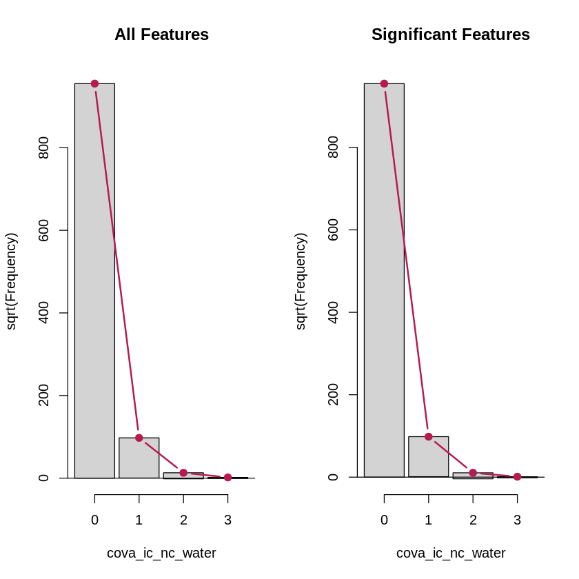

```r
par(mfrow = c(1, 2))
rootogram(zip_all,max = max(numclaims),main="All Features",style="hanging")
rootogram(zip_sign,max = max(numclaims),main="Significant Features",style="hanging")
```

All features model has deviance on numebr claims 2 and looks like more for only Significant features model

## Predicting Number of claims

I use XGB to predict the final result based on probabilities of number claims in each row.

```r
param0 <- list(
  "objective"  = "count:poisson"
  , "eval_metric" = "poisson-nloglik"
)
```

```r
#Adding  predicted probability values
#to training and testing dataset for each numclaims
#as separate column

training_all <- predict(zip_all, training_data, type='prob')
testing_all <- predict(zip_all, testing_data, type='prob')

training_sign <- predict(zip_sign, training_data, type='prob')
testing_sign <- predict(zip_sign, testing_data, type='prob')

for(unique_value in numclaims){

training_data[paste("zip_all", unique_value, sep = ".")] <- training_all[,as.numeric(unique_value)+1]
testing_data[paste("zip_all", unique_value, sep = ".")] <- testing_all[,as.numeric(unique_value)+1]

training_data[paste("zip_sign", unique_value, sep = ".")] <- training_sign[,as.numeric(unique_value)+1]
testing_data[paste("zip_sign", unique_value, sep = ".")] <- testing_sign[,as.numeric(unique_value)+1]

}
```

```r
#Features with probabilities listed by model
zip_all_features <- list();
zip_sign_features <- list();

i <- 1
for(unique_value in numclaims){
    zip_all_features[[i]] <- paste("zip_all", unique_value, sep = ".")
    zip_sign_features[[i]] <- paste("zip_sign", unique_value, sep = ".")

    i <- i + 1
}
```

```r
xgZIP_all_training = xgb.DMatrix(as.matrix(training_data[,unlist(zip_all_features)]), label = training_data$cova_ic_nc_water)
setinfo(xgZIP_all_training, "base_margin", log(training_data$ecy))

xgZIP_all_testing = xgb.DMatrix(as.matrix(testing_data[,unlist(zip_all_features)]), label = testing_data$cova_ic_nc_water)
setinfo(xgZIP_all_testing, "base_margin", log(testing_data$ecy))
```

TRUE

TRUE

```r
xgb = xgb.train(
  nrounds = 10000
  , params = param0
  , data = xgZIP_all_training
)
training_data$zip_all = predict(xgb, xgZIP_all_training)
testing_data$zip_all = predict(xgb, xgZIP_all_testing)
```

```r
xgZIP_sign_training = xgb.DMatrix(as.matrix(training_data[,unlist(zip_sign_features)]), label = training_data$cova_ic_nc_water)
setinfo(xgZIP_sign_training, "base_margin", log(training_data$ecy))

xgZIP_sign_testing = xgb.DMatrix(as.matrix(testing_data[,unlist(zip_sign_features)]), label = testing_data$cova_ic_nc_water)
setinfo(xgZIP_sign_testing, "base_margin", log(testing_data$ecy))
```

TRUE

TRUE

```r
xgb = xgb.train(
  nrounds = 10000
  , params = param0
  , data = xgZIP_sign_training
)
training_data$zip_sign = predict(xgb, xgZIP_sign_training)
testing_data$zip_sign = predict(xgb, xgZIP_sign_testing)
```

As an accuracy measure I use Normalized Weighted Gini:

```r
Testing_Gini <- data.frame ("All" = NormalizedWeightedGini(testing_data$cova_ic_nc_water,testing_data$zip_all,testing_data$ecy)
                   ,"Significant Only" = NormalizedWeightedGini(testing_data$cova_ic_nc_water,testing_data$zip_sign,testing_data$ecy)
                   )
Testing_Gini
```

A data.frame: 1 × 2

| All <dbl> | Significant.Only <dbl> |
| --- | --- |
| 0.2862043 | 0.2711677 |

Overall, the models are very close to each other. There is a difference in Normalized Weighted Gini which does NOT looks significant.

### K Fold Validation

TBD Does not work with Caret very strightforward and my manual approach is wrong somewhere

## Conclusion

- Normalization is needed to make the model work. I need to include normalized log columns in the datasets when it's extracted.
- I convert all other columns into factors but not sure if it's needed.
- I was not able to add into the model and test cova_deductible and log_norm_water_risk_sev_3_blk. It returns errors.
- usagetype returns NA in covariance matrix for some levels. Should I include in the model only "good" levels?
- Some predictors (like ordinanceorlawpct) are marked as significant but really it's a random component I feel.
- Significant features model has smaller AIC and BIC and should be better then All features model. The Normalized Weighted Genin is less in SIgnificant features model but probably the difference is not significant. Need F test to confirm.